# vector_2d_practice

Consider a box sitting on a frictionless surface viewed from above. Two force vectors are shown as red arrows.

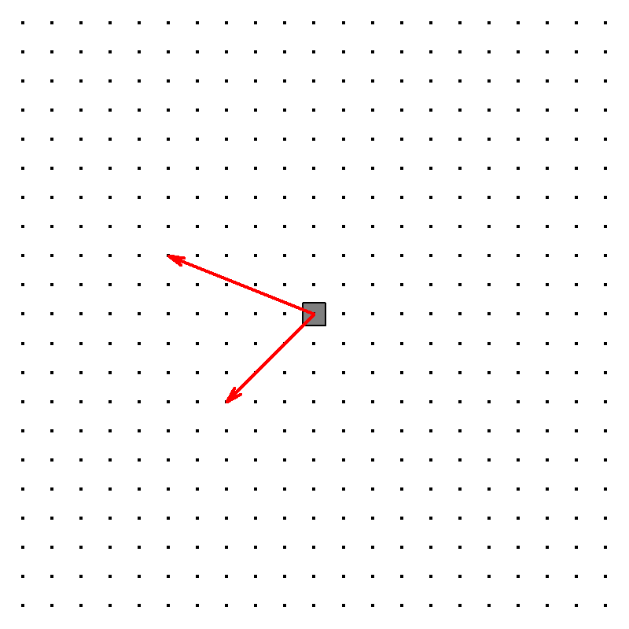

Which of the following options shows the **net** force acting on the box?

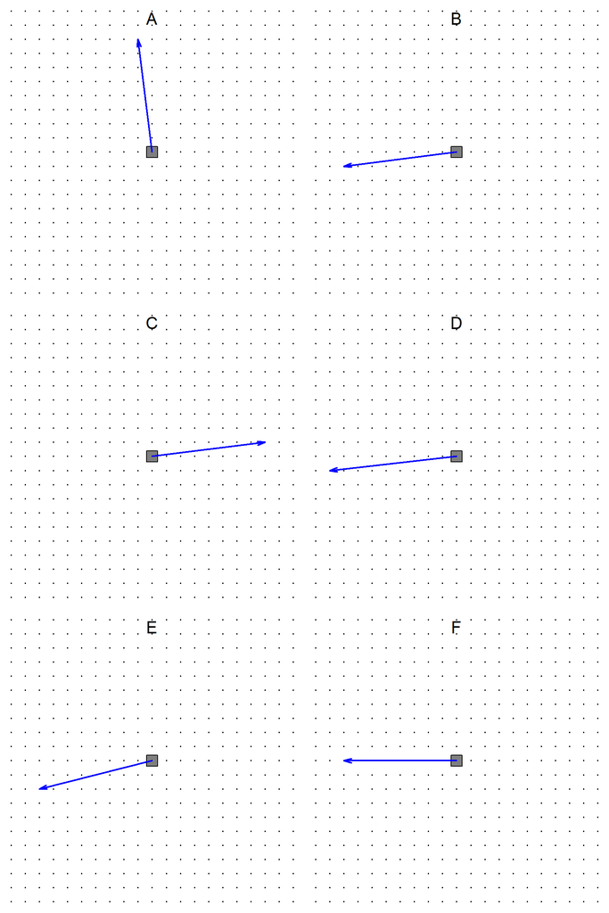

ABCDEF

Use the parallelogram rule.

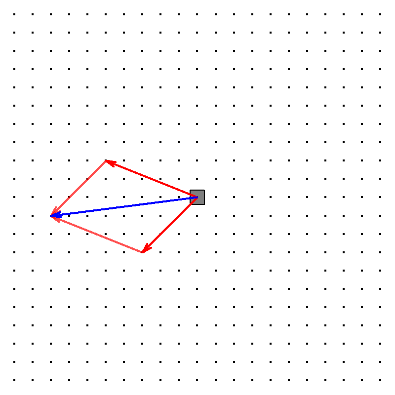

So the answer is B.

Consider a box sitting on a frictionless surface viewed from above. Two force vectors are shown as red arrows.

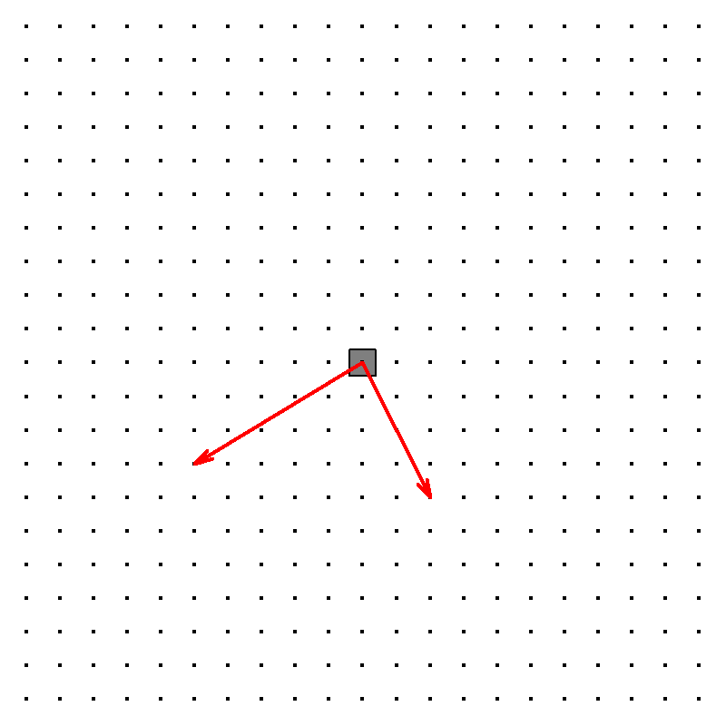

Which of the following options shows the **net** force acting on the box?

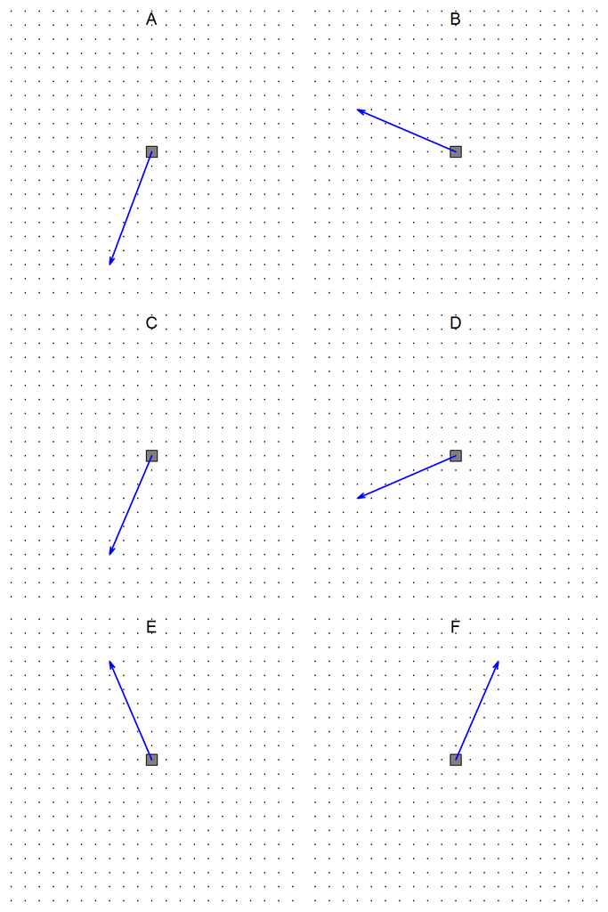

ABCDEF

Use the parallelogram rule.

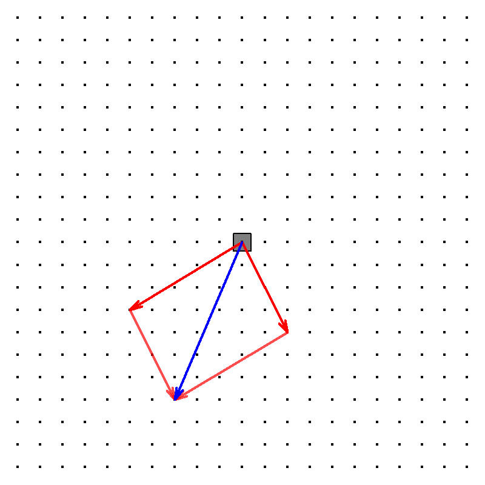

So the answer is C.

Consider a box sitting on a frictionless surface viewed from above. Two force vectors are shown as red arrows.

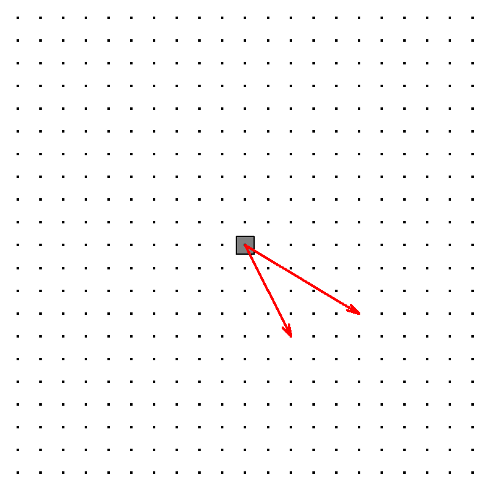

Which of the following options shows the **net** force acting on the box?

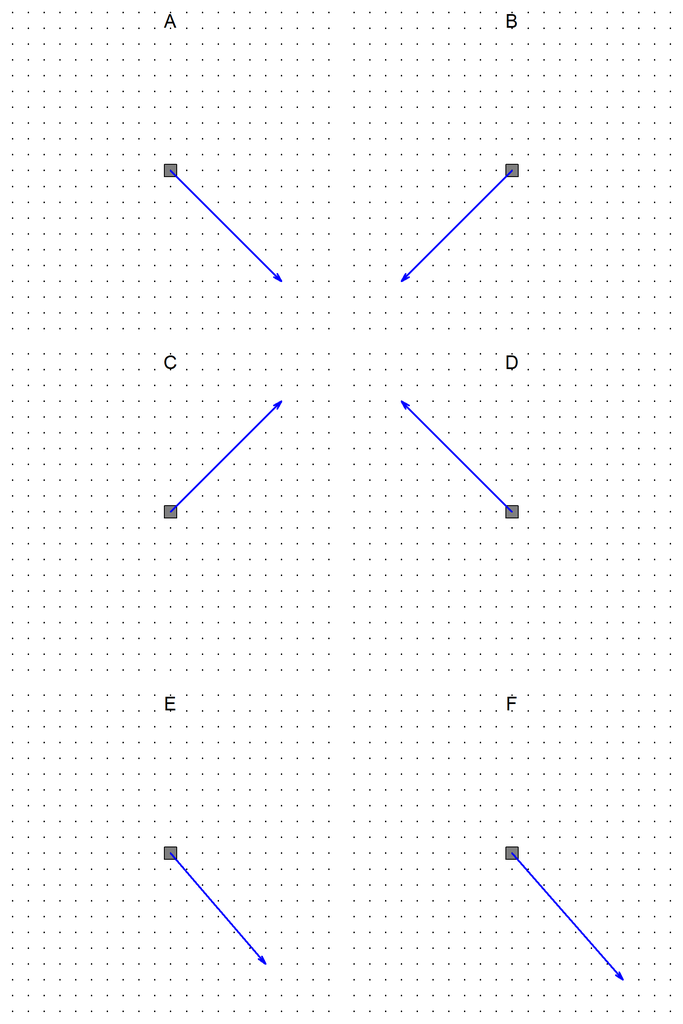

ABCDEF

Use the parallelogram rule.

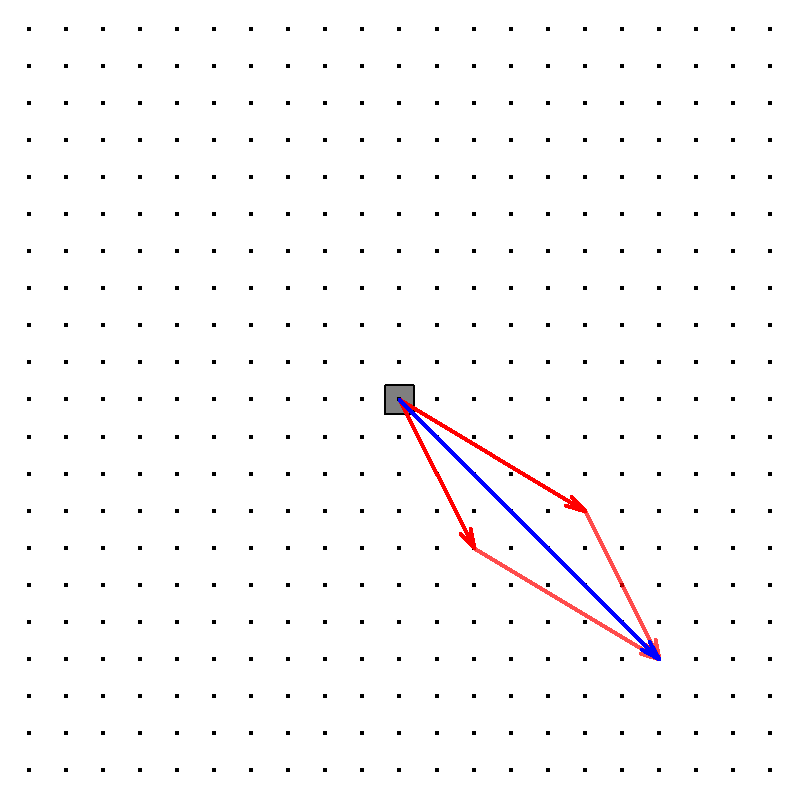

So the answer is A.

Consider a box sitting on a frictionless surface viewed from above. Two force vectors are shown as red arrows.

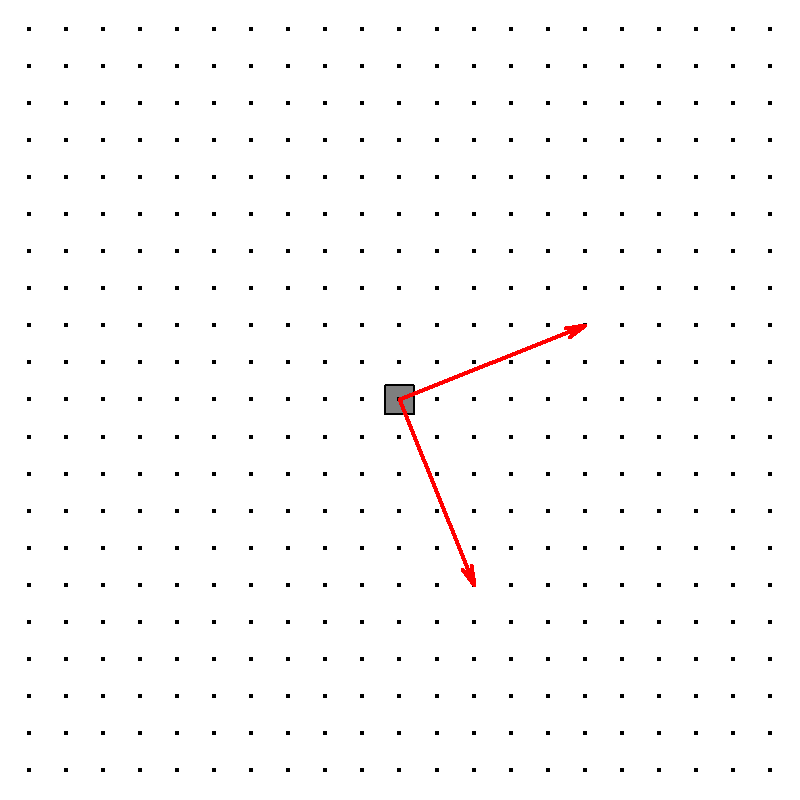

Which of the following options shows the **net** force acting on the box?

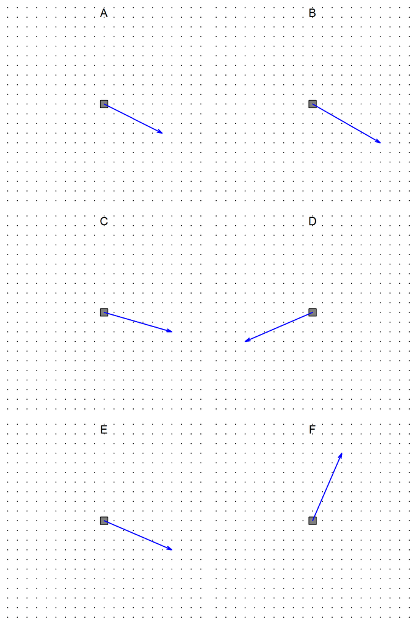

ABCDEF

Use the parallelogram rule.

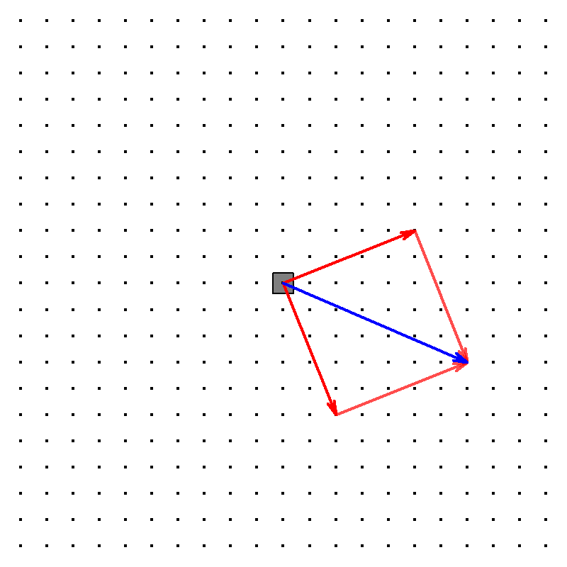

So the answer is E.

Consider a box sitting on a frictionless surface viewed from above. Two force vectors are shown as red arrows.

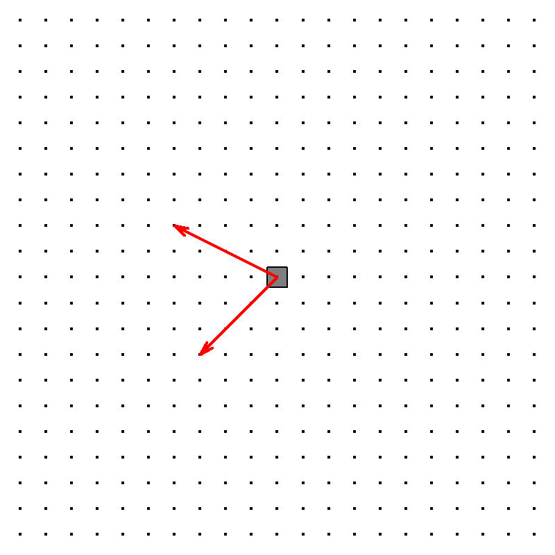

Which of the following options shows the **net** force acting on the box?

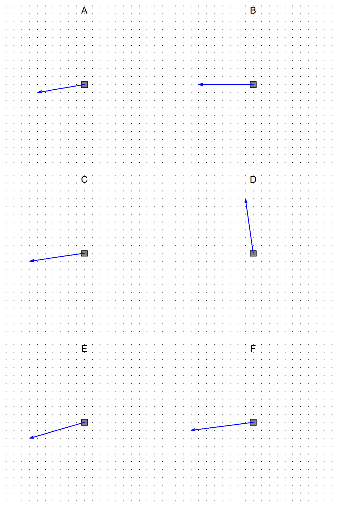

ABCDEF

Use the parallelogram rule.

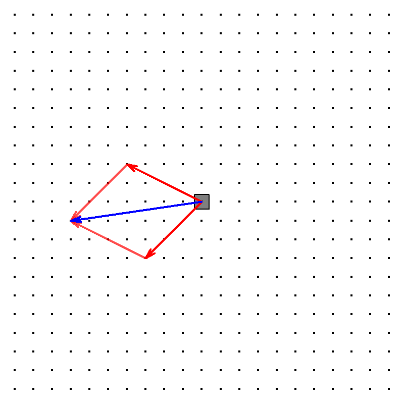

So the answer is C.

Consider a box sitting on a frictionless surface viewed from above. Two force vectors are shown as red arrows.

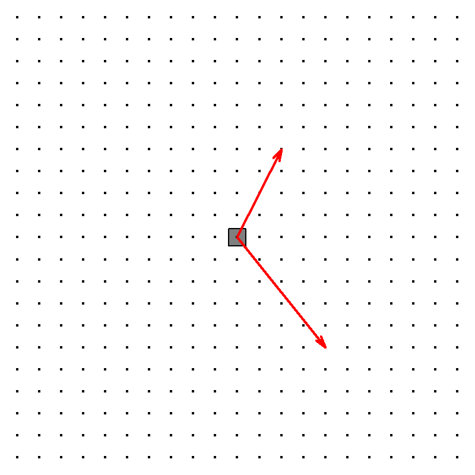

Which of the following options shows the **net** force acting on the box?

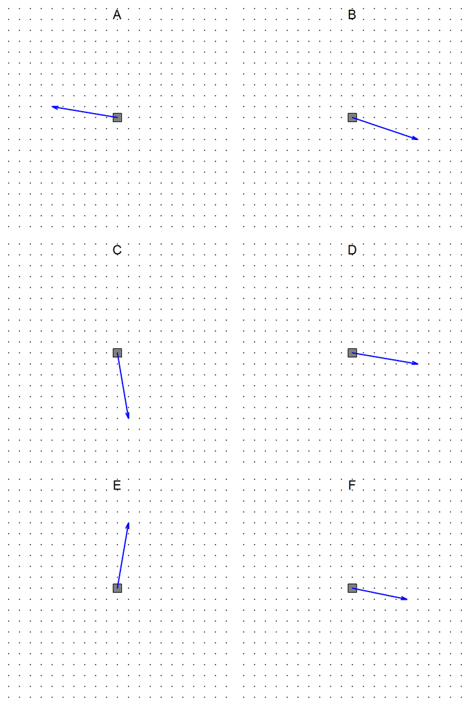

ABCDEF

Use the parallelogram rule.

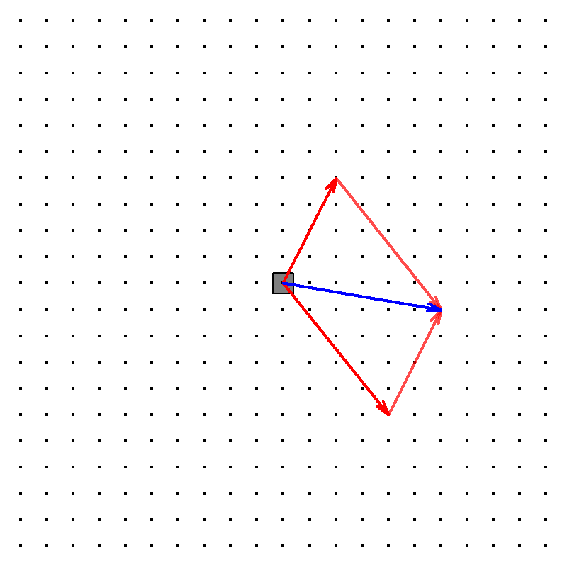

So the answer is D.

Consider a box sitting on a frictionless surface viewed from above. Two force vectors are shown as red arrows.

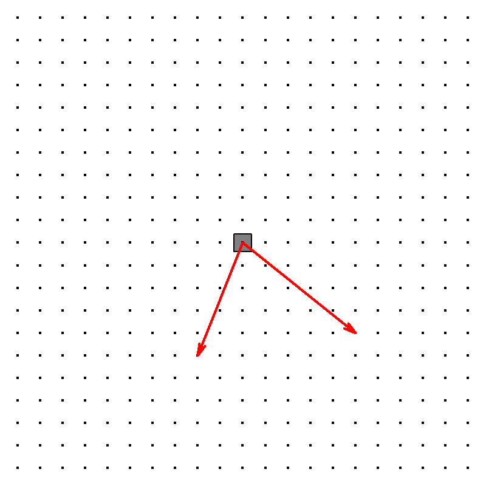

Which of the following options shows the **net** force acting on the box?

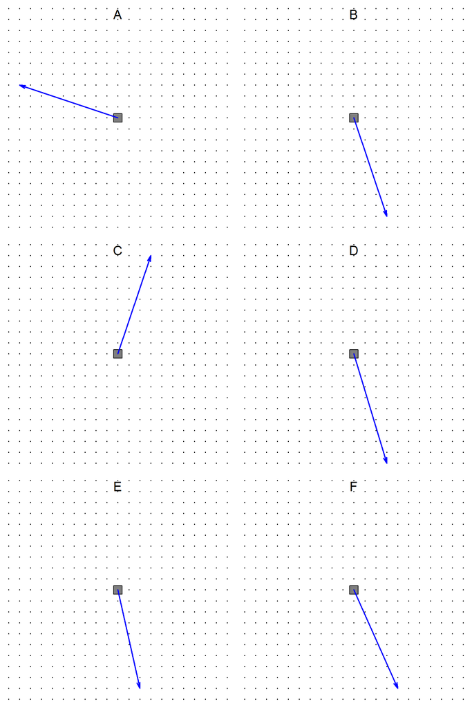

ABCDEF

Use the parallelogram rule.

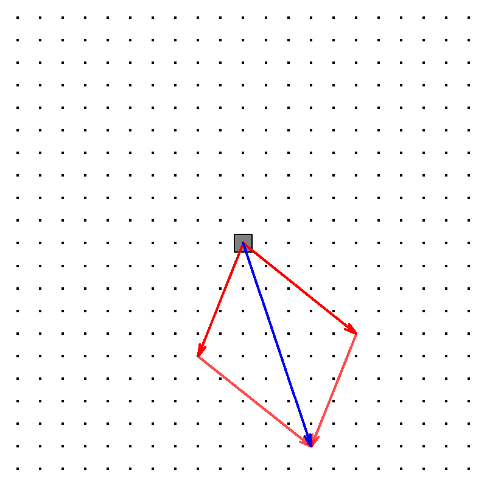

So the answer is B.

Consider a box sitting on a frictionless surface viewed from above. Two force vectors are shown as red arrows.

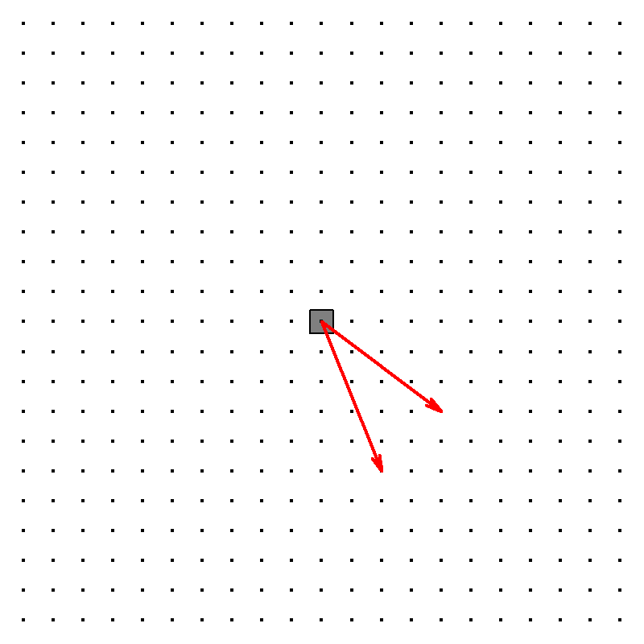

Which of the following options shows the **net** force acting on the box?

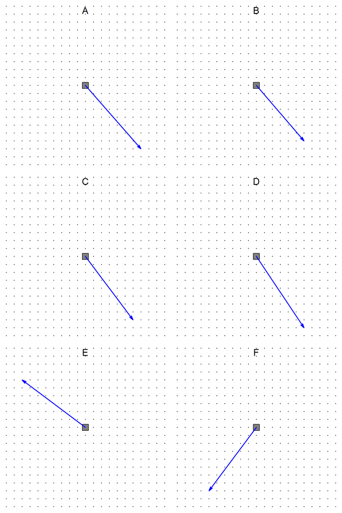

ABCDEF

Use the parallelogram rule.

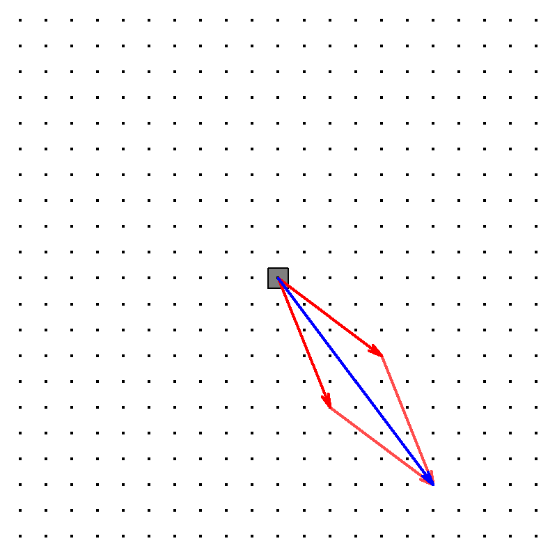

So the answer is C.

Consider a box sitting on a frictionless surface viewed from above. Two force vectors are shown as red arrows.

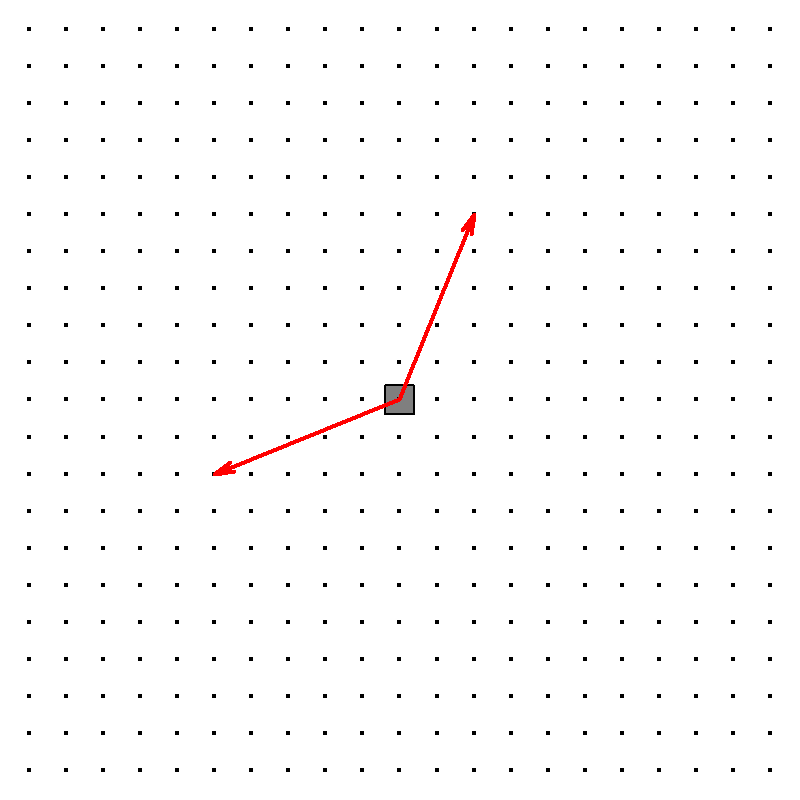

Which of the following options shows the **net** force acting on the box?

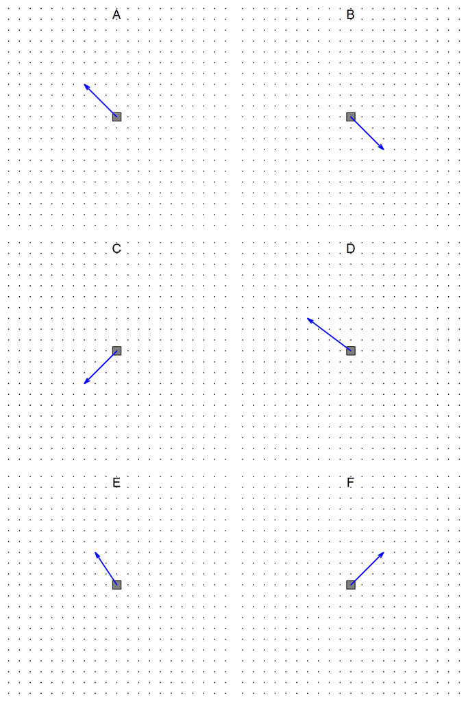

ABCDEF

Use the parallelogram rule.

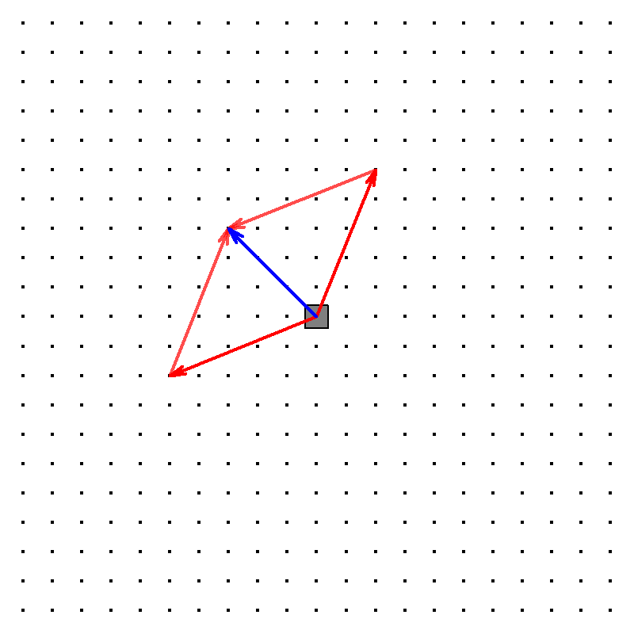

So the answer is A.

Consider a box sitting on a frictionless surface viewed from above. Two force vectors are shown as red arrows.

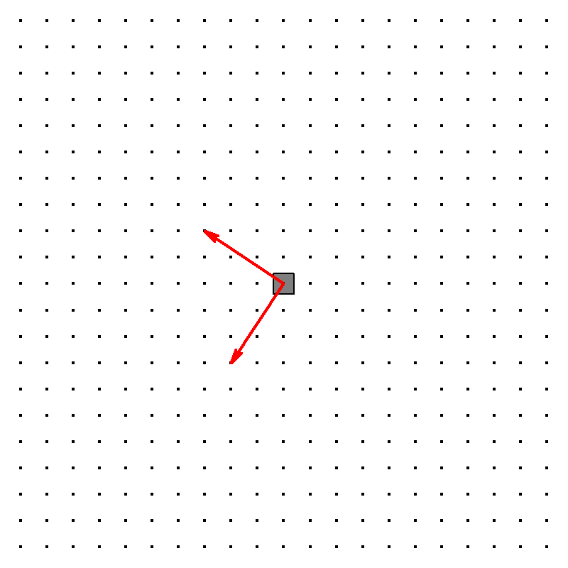

Which of the following options shows the **net** force acting on the box?

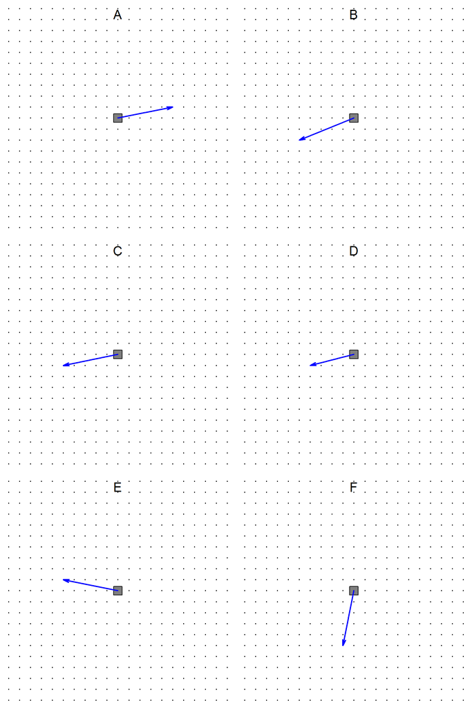

ABCDEF

Use the parallelogram rule.

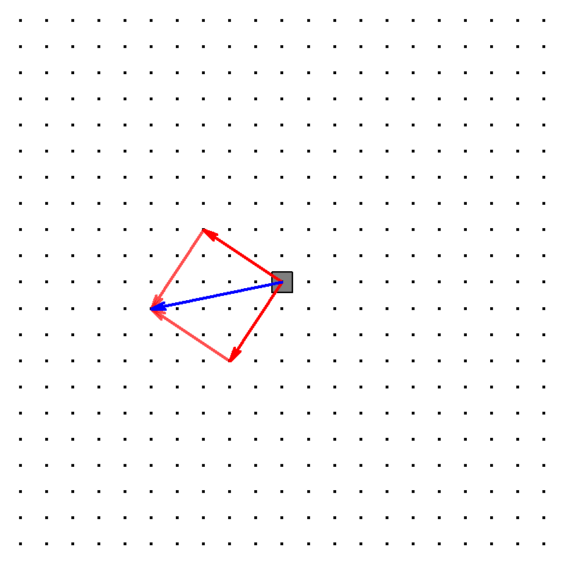

So the answer is C.